# Homework 3

Jeremy Hubinger, and Tamur Asar

## Project Work

### Instructions

**Goal:** Begin an analysis of your dataset to answer your **regression** research question.

**Collaboration:** Form a team (2-3 members) for the project and this part can be done as a team. Only one team member should submit a Project Work section. Make sure you include the full names of all of the members in your write up.

**Data cleaning:** If your dataset requires any cleaning (e.g., merging datasets, creation of new variables), first consult the R Resources page to see if your questions are answered there. If not, post on the #rcode-questions channel in our Slack workspace to ask for help. *Please ask for help early and regularly* to avoid stressful workloads.

### Required Analyses

1. **Initial investigation: ignoring nonlinearity (for now)**
   1. Use ordinary least squares (OLS) by using the `lm` engine and LASSO (`glmnet` engine) to build a series of initial regression models for your quantitative outcome as a function of the predictors of interest. (As part of data cleaning, exclude any variables that you don’t want to consider as predictors.)
      - You’ll need two model specifications, `lm_spec` and `lm_lasso_spec` (you’ll need to tune this one).
   2. For each set of variables, you’ll need a `recipe` with the `formula`, `data`, and pre-processing steps
      - You may want to have steps in your recipe that remove variables with near zero variance (`step_nzv()`), remove variables that are highly correlated with other variables (`step_corr()`), normalize all quantitative predictors (`step_normalize(all_numeric_predictors())`) and add indicator variables for any categorical variables (`step_dummy(all_nominal_predictors())`).
      - These models should not include any transformations to deal with nonlinearity. You’ll explore this in the next investigation.
   3. Estimate the test performance of the models using CV. Report and interpret (with units) the CV metric estimates along with a measure of uncertainty in the estimate (`std_error` is readily available when you used `collect_metrics(summarize=TRUE)`).
      - Compare estimated test performance across the models. Which models(s) might you prefer?
   4. Use residual plots to evaluate whether some quantitative predictors might be better modeled with nonlinear relationships.
   5. Which variables do you think are the most important predictors of your quantitative outcome? Justify your answer. Do the methods you’ve applied reach consensus on which variables are most important? What insights are expected? Surprising?
      - Note that if some (but not all) of the indicator terms for a categorical predictor are selected in the final models, the whole predictor should be treated as selected.

#### Your Work

a & b.

```r
# library statements
# read in data
library(readr)
library(ggplot2)
library(dplyr)
library(tidymodels)
tidymodels_prefer()

fires <- read_csv("forestfires.csv")
```

The dataset has a variety of variables that might impact the strength and likelihood of fires. These variables include mainly things about weather, like temperature, pressure, wind, rain, ect. The variable we are trying to predict is “area” which is the area burned by fires on that day.

```r
# data cleaning
fires <- fires %>%
    # we get rid of day because there isnt a huge reason that it should impact the fires, we are more interested in how weather factors impact fires, not day of the week
    select(-day) %>%
   filter(area > 0) %>%
    mutate(area = log(area+.1))
```

```r
# creation of cv folds
set.seed(88)
fires_cv10 <- vfold_cv(fires, v = 10)
```

We now fit multiple types of models. One model is fit using simple LM regression with all predictors. The second model is fit using LASSO regression to attempt to provide some amount of filtering to the model predictors. Both models are fit and compared later on.

```r
# model spec
lm_spec <-
    linear_reg() %>%
    set_engine(engine = 'lm') %>%
    set_mode('regression')

# this is the LASSO model
lm_lasso_spec <-
  linear_reg() %>%
  set_args(mixture = 1, penalty = tune()) %>%
  set_engine(engine = 'glmnet') %>%
  set_mode('regression')
```

```r
# recipes & workflows
# both models are fit with the same recipe because they both start with all predictors and all predictors are normalized
full_rec <- recipe(area ~ ., data = fires) %>%
    step_nzv(all_predictors()) %>% # removes variables with the same value
    step_normalize(all_numeric_predictors()) %>% # important standardization step for LASSO
    step_dummy(all_nominal_predictors())  # creates indicator variables for categorical variables

full_lm_wf <- workflow() %>%
    add_recipe(full_rec) %>%
    add_model(lm_spec)

lasso_wf_tune <- workflow() %>%
  add_recipe(full_rec) %>%
  add_model(lm_lasso_spec)
```

```r
# fit & tune models
full_lm_wf <- workflow() %>%
    add_recipe(full_rec) %>%
    add_model(lm_spec)

full_model <- fit(full_lm_wf, data = fires)
```

```r
# Tune Model (trying a variety of values of Lambda penalty)
penalty_grid <- grid_regular(
  penalty(range = c(-5, 3)), #log10 transformed
  levels = 30)

tune_output <- tune_grid( # new function for tuning parameters
  lasso_wf_tune, # workflow
  resamples = fires_cv10, # cv folds
  metrics = metric_set(rmse, mae),
  grid = penalty_grid # penalty grid defined above
)
```

```
## ! Fold07: preprocessor 1/1, model 1/1 (predictions): There are new levels in a fac...
```

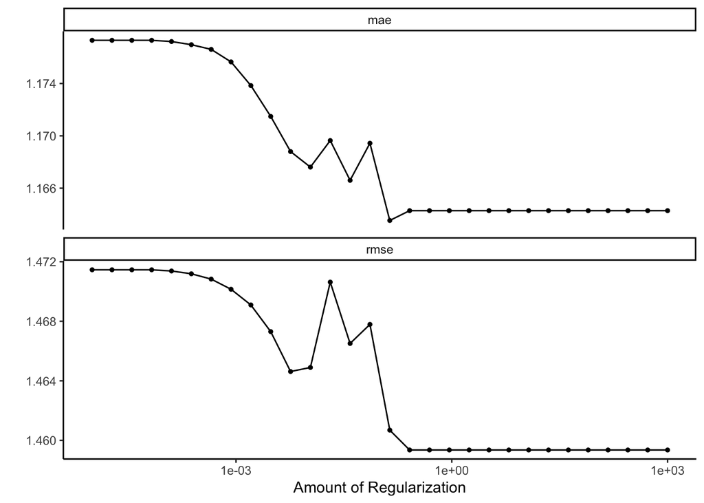

```r
 autoplot(tune_output) + theme_classic()
```

```r
 collect_metrics(tune_output) %>%
   filter(.metric == 'rmse') %>% # or choose mae
   select(penalty, rmse = mean)
```

```
## # A tibble: 30 × 2
##      penalty  rmse
##        <dbl> <dbl>
##  1 0.00001    1.47
##  2 0.0000189  1.47
##  3 0.0000356  1.47
##  4 0.0000672  1.47
##  5 0.000127   1.47
##  6 0.000240   1.47
##  7 0.000452   1.47
##  8 0.000853   1.47
##  9 0.00161    1.47
## 10 0.00304    1.47
## # … with 20 more rows
```

```r
 best_penalty <- select_best(tune_output, metric = 'rmse')

best_penalty
```

```
## # A tibble: 1 × 2
##   penalty .config
##     <dbl> <chr>
## 1   0.259 Preprocessor1_Model17
```

```r
final_wf <- finalize_workflow(lasso_wf_tune, best_penalty)

final_fit <- fit(final_wf, data = fires)

tidy(final_fit)
```

```
## # A tibble: 19 × 3
##    term        estimate penalty
##    <chr>          <dbl>   <dbl>
##  1 (Intercept)     1.89   0.259
##  2 X               0      0.259
##  3 Y               0      0.259
##  4 FFMC            0      0.259
##  5 DMC             0      0.259
##  6 DC              0      0.259
##  7 ISI             0      0.259
##  8 temp            0      0.259
##  9 RH              0      0.259
## 10 wind            0      0.259
## 11 month_aug       0      0.259
## 12 month_dec       0      0.259
## 13 month_feb       0      0.259
## 14 month_jul       0      0.259
## 15 month_jun       0      0.259
## 16 month_mar       0      0.259
## 17 month_may       0      0.259
## 18 month_oct       0      0.259
## 19 month_sep       0      0.259
```

It seems as though all variables were set to 0 with LASSO. This is very interesting because it indicates that none of the variables make a significant effect in the predictive power of the model.

```r
#  calculate/collect CV metrics

full_model %>% tidy()
```

```
## # A tibble: 19 × 5
##    term        estimate std.error statistic  p.value
##    <chr>          <dbl>     <dbl>     <dbl>    <dbl>
##  1 (Intercept)   0.694      1.20      0.580 0.562
##  2 X             0.134      0.108     1.24  0.215
##  3 Y            -0.126      0.107    -1.18  0.239
##  4 FFMC          0.0341     0.152     0.224 0.823
##  5 DMC           0.600      0.168     3.58  0.000416
##  6 DC           -1.25       0.457    -2.73  0.00677
##  7 ISI          -0.150      0.145    -1.04  0.300
##  8 temp          0.303      0.195     1.55  0.122
##  9 RH            0.0273     0.136     0.201 0.841
## 10 wind          0.0971     0.105     0.928 0.354
## 11 month_aug     0.894      1.30      0.687 0.493
## 12 month_dec     1.95       1.10      1.77  0.0778
## 13 month_feb    -0.252      0.867    -0.291 0.772
## 14 month_jul     0.124      1.11      0.112 0.911
## 15 month_jun    -0.514      1.05     -0.490 0.624
## 16 month_mar    -0.399      0.812    -0.491 0.624
## 17 month_may     0.991      1.64      0.603 0.547
## 18 month_oct     3.29       1.58      2.08  0.0384
## 19 month_sep     2.17       1.46      1.48  0.139
```

```r
best_penalty <- select_best(tune_output, metric = 'rmse')

final_wf <- finalize_workflow(lasso_wf_tune, best_penalty)

final_fit <- fit(final_wf, data = fires)

tidy(final_fit)
```

```
## # A tibble: 19 × 3
##    term        estimate penalty
##    <chr>          <dbl>   <dbl>
##  1 (Intercept)     1.89   0.259
##  2 X               0      0.259
##  3 Y               0      0.259
##  4 FFMC            0      0.259
##  5 DMC             0      0.259
##  6 DC              0      0.259
##  7 ISI             0      0.259
##  8 temp            0      0.259
##  9 RH              0      0.259
## 10 wind            0      0.259
## 11 month_aug       0      0.259
## 12 month_dec       0      0.259
## 13 month_feb       0      0.259
## 14 month_jul       0      0.259
## 15 month_jun       0      0.259
## 16 month_mar       0      0.259
## 17 month_may       0      0.259
## 18 month_oct       0      0.259
## 19 month_sep       0      0.259
```

Based on the above information, using the LASSO model to tell what variables are the most important (which is none). This is much more readable than the LM model which has a lot of importance on a lot of different variables which don’t seem to matter, and actually hurt the model’s performance on test data.

```r
LASSO_model_cv <- fit_resamples(final_fit,
  resamples = fires_cv10,
  metrics = metric_set(rmse, rsq, mae)
)
```

[output not shown]

[output not shown]

[output not shown]

[output not shown]

[output not shown]

[output not shown]

[output not shown]

[output not shown]

[output not shown]

[output not shown]

[output not shown]

```r
LASSO_model_cv %>% collect_metrics(summarize=TRUE)
```

```
## # A tibble: 3 × 6
##   .metric .estimator   mean     n std_err .config
##   <chr>   <chr>       <dbl> <int>   <dbl> <chr>
## 1 mae     standard     1.16    10  0.0697 Preprocessor1_Model1
## 2 rmse    standard     1.46    10  0.0802 Preprocessor1_Model1
## 3 rsq     standard   NaN        0 NA      Preprocessor1_Model1
```

```r
LM_model_cv <- fit_resamples(full_model,
  resamples = fires_cv10,
  metrics = metric_set(rmse, rsq, mae)
)
```

```
## ! Fold07: preprocessor 1/1, model 1/1 (predictions): There are new levels in a fac...
```

```r
LM_model_cv %>% collect_metrics(summarize=TRUE)
```

```
## # A tibble: 3 × 6
##   .metric .estimator   mean     n std_err .config
##   <chr>   <chr>       <dbl> <int>   <dbl> <chr>
## 1 mae     standard   1.18      10  0.0634 Preprocessor1_Model1
## 2 rmse    standard   1.47      10  0.0699 Preprocessor1_Model1
## 3 rsq     standard   0.0441    10  0.0124 Preprocessor1_Model1
```

As we can see in the metrics above, the normal LM model with all the variables performs worse than the LASSO model which is much simpler. Because of the better performance (likely due to overfitting in the LM model’s case) and simpler model coefficients we prefer the LASSO model at this point, but better models are yet to come.

```r
# visual residuals
final_fit %>% tidy() %>% filter(estimate != 0)
```

```
## # A tibble: 1 × 3
##   term        estimate penalty
##   <chr>          <dbl>   <dbl>
## 1 (Intercept)     1.89   0.259
```

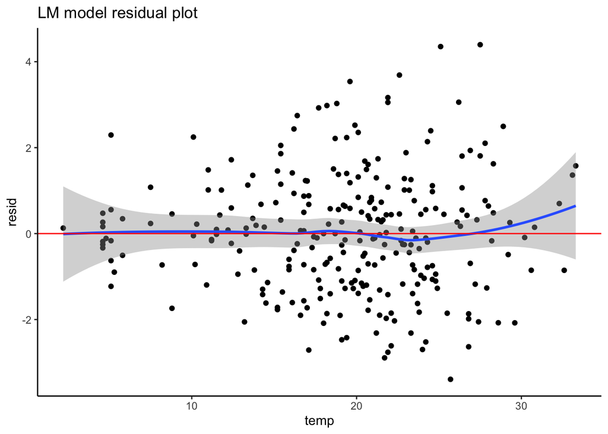

```r
lasso_mod_out <- final_fit %>%
    predict(new_data = fires) %>%
    bind_cols(fires) %>%
    mutate(resid = area - .pred)

lm_mod_out <- full_model %>%
    predict(new_data = fires) %>%
    bind_cols(fires) %>%
    mutate(resid = area - .pred)

ggplot(lm_mod_out, aes(x = temp, y = resid)) +
    geom_point() +
    geom_smooth() +
    geom_hline(yintercept = 0, color = "red") +
    theme_classic() +
    ggtitle("LM model residual plot")
```

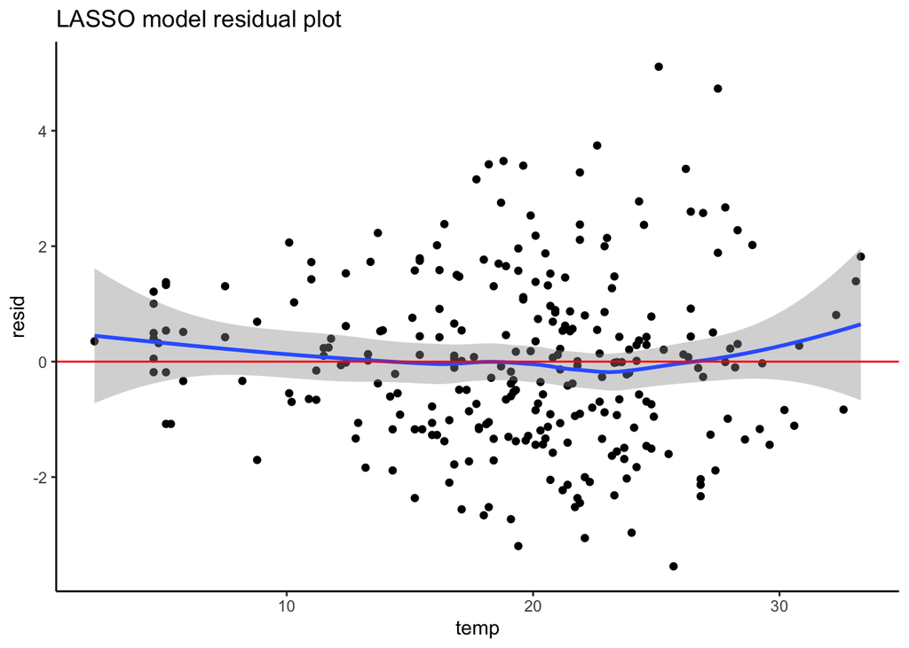

```r
ggplot(lasso_mod_out, aes(x = temp, y = resid)) +
    geom_point() +
    geom_smooth() +
    geom_hline(yintercept = 0, color = "red") +
    theme_classic() +
    ggtitle("LASSO model residual plot")
```

As mentioned earlier, the variables don’t seem to be impactful on the performance of the model, Which is interesting because it means that the predictors are fairly useless when trying to predict fires, this just goes to show the unpredictive nature of wildfires. We can also see that in the residual plots above, given that the LM model and the LASSO model (which has all coefficients set to 0) because the residual plots don’t look very different.

Part 2:

```r
# Natural Spline Recipe
ns2_rec <- full_rec %>%
  step_ns(temp, deg_free = 3) %>%
  step_ns(RH, deg_free = 3) %>%
  step_ns(DMC, deg_free = 3) %>%
  step_ns(FFMC, deg_free = 3) %>%
  step_ns(DC, deg_free = 3) %>%
  step_ns(ISI, deg_free = 3) %>%
  step_ns(wind, deg_free = 3) # natural cubic spline (higher deg_free means more knots)

# Workflow (Recipe + Model)
wf <- workflow() %>%
    add_recipe(ns2_rec) %>%
    add_model(lm_spec)

# CV to Evaluate
cv_output <- fit_resamples(
  wf, # workflow
  resamples = fires_cv10, # cv folds
  metrics = metric_set(rsq, mae, rmse)
)
```

```
## ! Fold07: preprocessor 1/1, model 1/1 (predictions): There are new levels in a fac...
```

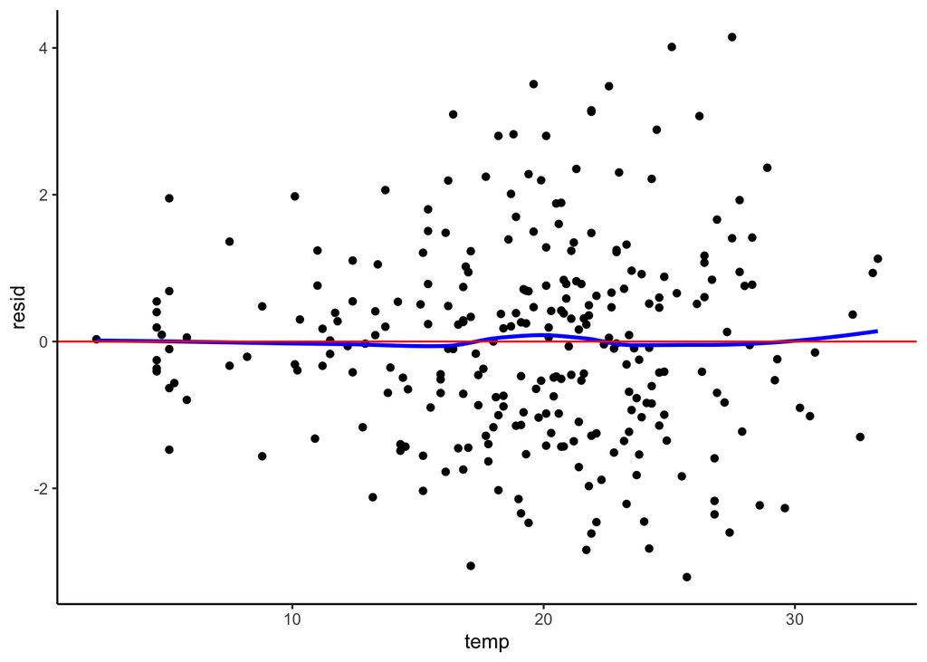

```r
# Fit with all data
ns_mod <- fit(
  wf, #workflow
  data = fires
)

ns_mod_output <- fires %>%
  bind_cols(predict(ns_mod, new_data = fires)) %>%
    mutate(resid = area - .pred)

ggplot(ns_mod_output, aes(y=resid,x=temp)) +
    geom_point() +
    geom_smooth(color = "blue", se = FALSE) +
    geom_hline(yintercept = 0, color = "red") +
    theme_classic()
```

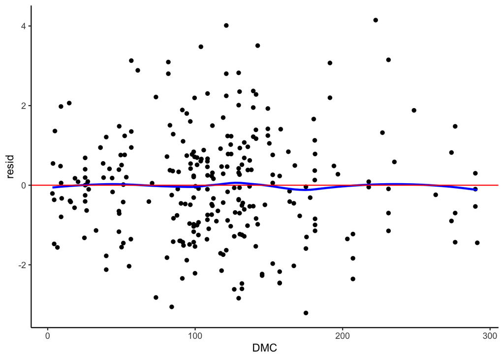

```r
ggplot(ns_mod_output, aes(y=resid,x=DMC)) +
    geom_point() +
    geom_smooth(color = "blue", se = FALSE) +
    geom_hline(yintercept = 0, color = "red") +
    theme_classic()
```

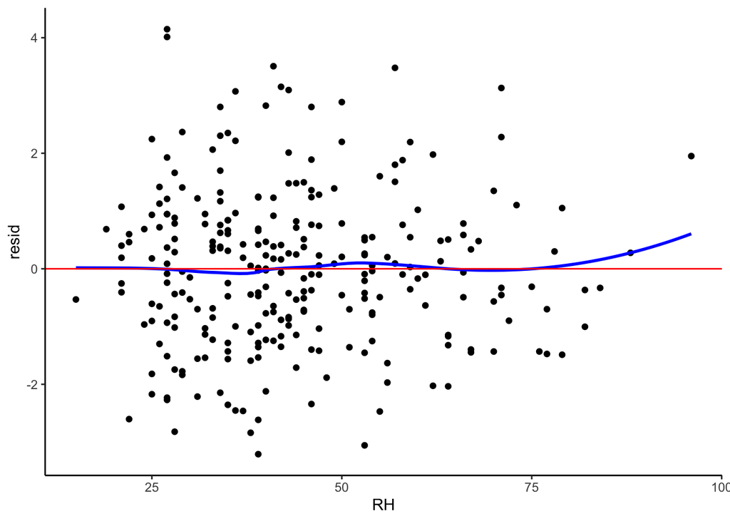

```r
ggplot(ns_mod_output, aes(y=resid,x=RH)) +
    geom_point() +
    geom_smooth(color = "blue", se = FALSE) +
    geom_hline(yintercept = 0, color = "red") +
    theme_classic()
```

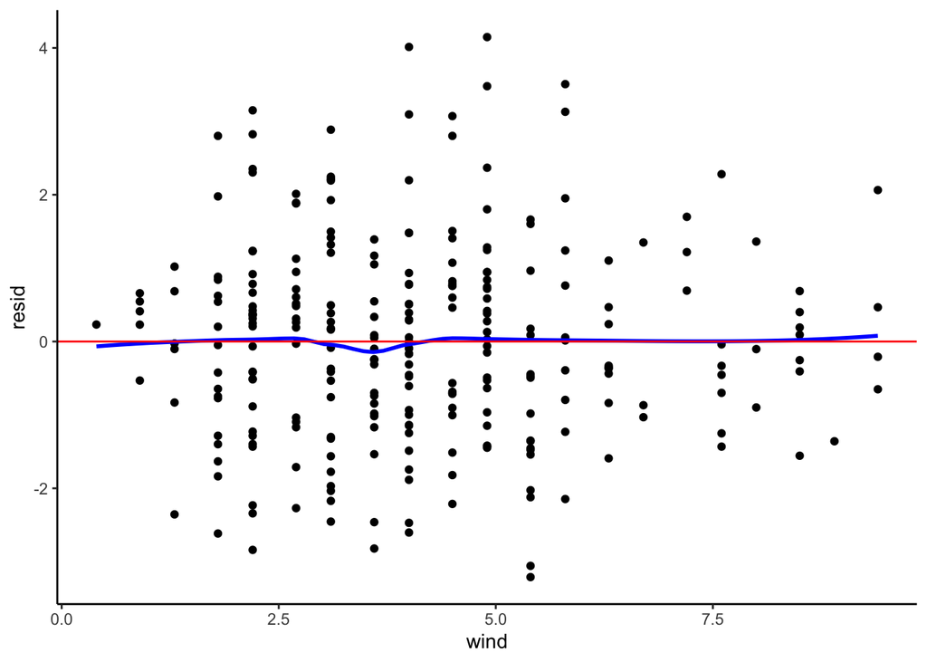

```r
ggplot(ns_mod_output, aes(y=resid,x=wind)) +
    geom_point() +
    geom_smooth(color = "blue", se = FALSE) +
    geom_hline(yintercept = 0, color = "red") +
    theme_classic()
```

```r
cv_output %>% collect_metrics(summarize = TRUE) # splines
```

```
## # A tibble: 3 × 6
##   .metric .estimator   mean     n std_err .config
##   <chr>   <chr>       <dbl> <int>   <dbl> <chr>
## 1 mae     standard   1.22      10  0.0663 Preprocessor1_Model1
## 2 rmse    standard   1.53      10  0.0802 Preprocessor1_Model1
## 3 rsq     standard   0.0340    10  0.0117 Preprocessor1_Model1
```

```r
LM_model_cv %>% collect_metrics(summarize=TRUE)
```

```
## # A tibble: 3 × 6
##   .metric .estimator   mean     n std_err .config
##   <chr>   <chr>       <dbl> <int>   <dbl> <chr>
## 1 mae     standard   1.18      10  0.0634 Preprocessor1_Model1
## 2 rmse    standard   1.47      10  0.0699 Preprocessor1_Model1
## 3 rsq     standard   0.0441    10  0.0124 Preprocessor1_Model1
```

```r
LASSO_model_cv %>% collect_metrics(summarize=TRUE)
```

```
## # A tibble: 3 × 6
##   .metric .estimator   mean     n std_err .config
##   <chr>   <chr>       <dbl> <int>   <dbl> <chr>
## 1 mae     standard     1.16    10  0.0697 Preprocessor1_Model1
## 2 rmse    standard     1.46    10  0.0802 Preprocessor1_Model1
## 3 rsq     standard   NaN        0 NA      Preprocessor1_Model1
```

GAM WITH SPLINES

```r
gam_spec <-
  gen_additive_mod() %>%
  set_engine(engine = 'mgcv') %>%
  set_mode('regression')

gam_mod <- fit(gam_spec,
    area ~ s(DMC) + s(temp) + s(RH) + s(wind) + s(ISI) + s(DC) + s(FFMC),
    data = fires
)
```

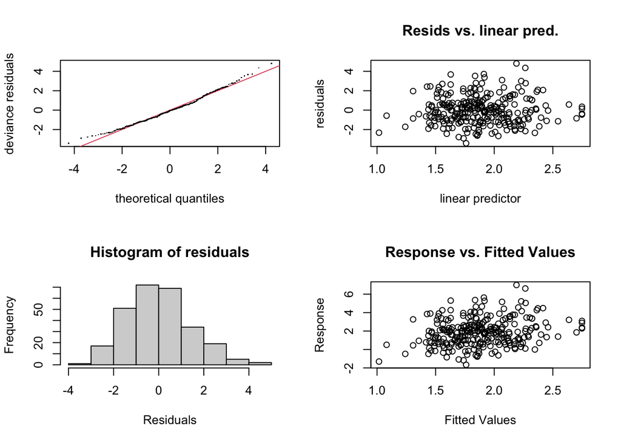

```
##
## Method: GCV   Optimizer: magic
## Smoothing parameter selection converged after 17 iterations.
## The RMS GCV score gradient at convergence was 5.418353e-08 .
## The Hessian was positive definite.
## Model rank =  64 / 64
##
## Basis dimension (k) checking results. Low p-value (k-index<1) may
## indicate that k is too low, especially if edf is close to k'.
##
##           k'  edf k-index p-value
## s(DMC)  9.00 1.00    0.86    0.01 **
## s(temp) 9.00 1.00    0.99    0.43
## s(RH)   9.00 2.11    0.98    0.35
## s(wind) 9.00 1.49    0.81  <2e-16 ***
## s(ISI)  9.00 1.00    0.80  <2e-16 ***
## s(DC)   9.00 1.00    0.83  <2e-16 ***
## s(FFMC) 9.00 1.00    0.80  <2e-16 ***
## ---
## Signif. codes:  0 '***' 0.001 '**' 0.01 '*' 0.05 '.' 0.1 ' ' 1
```

```r
par(mfrow=c(2,2))
gam_mod %>% pluck('fit') %>% mgcv::gam.check()
```

```r
gam_mod %>% pluck('fit') %>% summary()
```

```
##
## Family: gaussian
## Link function: identity
##
## Formula:
## area ~ s(DMC) + s(temp) + s(RH) + s(wind) + s(ISI) + s(DC) +
##     s(FFMC)
##
## Parametric coefficients:
##             Estimate Std. Error t value Pr(>|t|)
## (Intercept)  1.88540    0.08896   21.19   <2e-16 ***
## ---
## Signif. codes:  0 '***' 0.001 '**' 0.01 '*' 0.05 '.' 0.1 ' ' 1
##
## Approximate significance of smooth terms:
##           edf Ref.df     F p-value
## s(DMC)  1.000  1.000 2.421  0.1210
## s(temp) 1.000  1.000 0.215  0.6430
## s(RH)   2.106  2.668 1.985  0.1624
## s(wind) 1.489  1.832 0.591  0.4394
## s(ISI)  1.000  1.000 3.312  0.0699 .
## s(DC)   1.000  1.000 0.603  0.4381
## s(FFMC) 1.000  1.000 0.141  0.7075
## ---
## Signif. codes:  0 '***' 0.001 '**' 0.01 '*' 0.05 '.' 0.1 ' ' 1
##
## R-sq.(adj) =  0.0217   Deviance explained =  5.3%
## GCV = 2.2154  Scale est. = 2.1367    n = 270
```

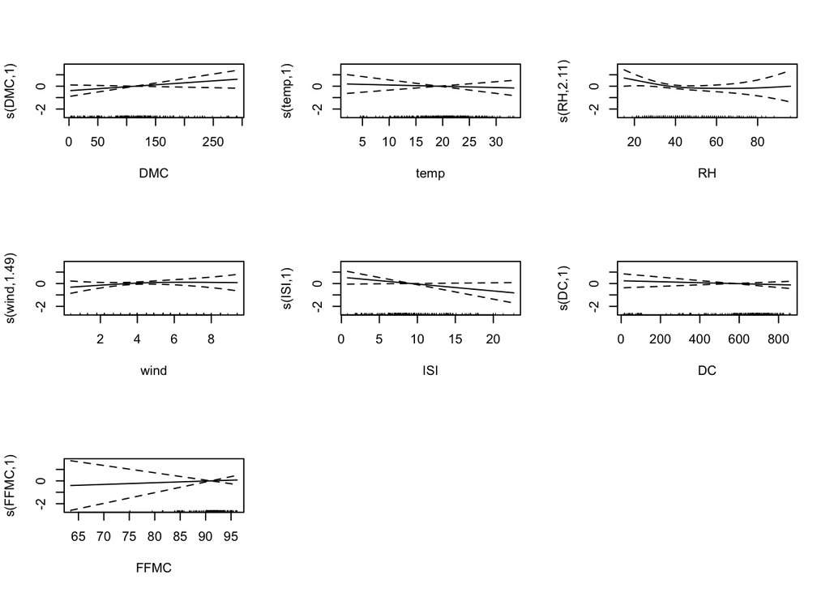

```r
gam_mod %>% pluck('fit') %>% plot( all.terms = TRUE, pages = 1)
```

From the plots we can see that most of our data is linear (hovering around 1 edf with the default range) while RH is the most nonlinear plot (with an edf of 2). As GAM regression is primarily to generate models explaining nonlinearity in multiple predictors, GAMs are most likely not the ideal model to be using in order to perform predictions on the data.